# Tarea_12_de_noviembre_2021

Moises Alejandro Enriquez Vargas

22/11/2021

*Antes de cargar cualquier cosa voy a correr una función que voy a usar más adelantes. Si no les gusta mucho R pueden ignorar esta parte pero si les gusta R pueden tratar de adivinar como funciona esto, cualquier duda me escriben.*

```r
plot.norm.test <- function (data, data2 = NULL, mu0 = NULL, gamma = 0.95, sigma = NULL, sigma2 = NULL, cola = "ambas", main = "", ylab ="Z", xlab ="Probabilidad", col.NR ="blue", col.R = "red", col.t = "black") {
  alfa = 1-gamma
  if(is.null(data2)) {
    est.prueb <- (mean(data)-mu0)/(sigma/sqrt(length(data)))
    if(cola == "izquierda"){
      ZR.Inf <- -5
      ZR.Sup <- qnorm(alfa)
      zona.NR=seq(ZR.Sup,5,length.out = 100)
      xNR <- c(ZR.Sup,zona.NR,5)
      yNR <- c(0,dnorm(zona.NR),0)
      xR <- c(-5,seq(-5,ZR.Sup,length.out = 100),ZR.Sup)
      yR <- c(0,dnorm(seq(-5,ZR.Sup,length.out = 100)),0)
      plot(x= seq(-5,5,length.out= length(zona.NR)), y = dnorm(seq(-5,5,length.out = length(zona.NR))), type = "l", bty = "l", main = main, ylab = ylab, xlab = xlab)
      polygon(xNR, yNR, col= col.NR)
      polygon(xR, yR, col= col.R)
      text(x = c(0,-3.5), y = c(0.2,0.1), labels = c("Zona de \n no rechazo", "Zona de rechazo"), col = c("white",1))
      if(est.prueb < -5){
        text(x = -4.5, y = 0.06, labels ="t", cex = 2, col = "black")
        text(x = -4.5, y = 0.03, labels ="<-", cex = 2, col = "black")
      }else if (est.prueb > 5){
        text(x = 4.5, y = 0.06, labels ="t", cex = 2, col = "black")
        text(x = 4.8, y = 0.06, labels ="->", cex = 2, col = "black")
      }else {
        text(x = est.prueb, y = 0.06, labels ="t", cex = 2, col = "black")
        text(x = est.prueb, y = 0.03, labels ="<-", cex = 2, col = "black", srt = 90)
      }
    }else if (cola == "derecha"){
      ZR.Inf <- qnorm(1-alfa)
      ZR.Sup <- 5
      zona.NR=seq(-5,ZR.Inf,length.out = 100)
      xNR <- c(-5,zona.NR,ZR.Inf)
      yNR <- c(0,dnorm(zona.NR),0)
      xR <- c(ZR.Inf,seq(ZR.Inf, 5,length.out = 100),5)
      yR <- c(0,dnorm(seq(ZR.Inf, 5,length.out = 100)),0)
      plot(x= seq(-5,5,length.out= length(zona.NR)), y = dnorm(seq(-5,5,length.out = length(zona.NR))), type = "l", bty = "l", main = main, ylab = ylab, xlab = xlab)
      polygon(xNR, yNR, col= col.NR)
      polygon(xR, yR, col= col.R)
      text(x = c(0,3.5), y = c(0.2,0.1), labels = c("Zona de \n no rechazo", "Zona de rechazo"), col = c("white",1))
      if(est.prueb > 5){
        text(x = 4.5, y = 0.06, labels ="t", cex = 2, col = "black")
        text(x = 4.5, y = 0.03, labels ="->", cex = 2, col = "black")
      } else if (est.prueb < -5){
        text(x = -4.5, y = 0.06, labels ="t", cex = 2, col = "black")
        text(x = -4.8, y = 0.06, labels ="<-", cex = 2, col = "black")
      } else {
        text(x = est.prueb, y = 0.06, labels ="t", cex = 2, col = "black")
        text(x = est.prueb, y = 0.03, labels ="<-", cex = 2, col = "black", srt = 90)
      }
    }else if (cola == "ambas"){
      ZR.Inf <- qnorm(alfa/2)
      ZR.Sup <- qnorm(1-alfa/2)
      zona.NR=seq(ZR.Inf,ZR.Sup,length.out = 100)
      xNR <- c(ZR.Inf,zona.NR,ZR.Sup)
      yNR <- c(0,dnorm(zona.NR),0)
      xR.Inf <- c(-5,seq(-5,ZR.Inf,length.out = 100),ZR.Inf)
      yR.Inf <- c(0,dnorm(seq(-5,ZR.Inf,length.out = 100)),0)
      xR.Sup <- c(ZR.Sup,seq(ZR.Sup, 5,length.out = 100),5)
      yR.Sup <- c(0,dnorm(seq(ZR.Sup, 5,length.out = 100)),0)
      plot(x= seq(-5,5,length.out= length(zona.NR)), y = dnorm(seq(-5,5,length.out = length(zona.NR))), type = "l", bty = "l", main = main, ylab = ylab, xlab = xlab)
      polygon(xNR, yNR, col= col.NR)
      polygon(xR.Inf, yR.Inf, col= col.R)
      polygon(xR.Sup, yR.Sup, col= col.R)
      text(x = c(0,-3.5,3.5), y = c(0.2,0.1,0.1), labels = c("Zona de \n no rechazo", "Zona de rechazo","Zona de rechazo"), col = c("white",1,1))
      if(est.prueb < -5){
        text(x = -4.5, y = 0.06, labels ="t", cex = 2, col = col.t)
        text(x = -4.8, y = 0.06, labels ="<-", cex = 2, col = col.t)
      }else if(est.prueb > 5){
        text(x = 4.5, y = 0.06, labels ="t", cex = 2, col = col.t)
        text(x = 4.8, y = 0.03, labels ="->", cex = 2, col = col.t)
      }else {
        text(x = est.prueb, y = 0.06, labels ="t", cex = 2, col = col.t)
        text(x = est.prueb, y = 0.03, labels ="<-", cex = 2, col = col.t, srt = 90)
      }
    }
  } else {
    est.prueb <- (mean(data)-mean(data2))/sqrt((sigma/length(data))+(sigma2/length(data2)))
    if(cola == "izquierda"){
      ZR.Inf <- -5
      ZR.Sup <- qnorm(alfa)
      zona.NR=seq(ZR.Sup,5,length.out = 100)
      xNR <- c(ZR.Sup,zona.NR,5)
      yNR <- c(0,dnorm(zona.NR),0)
      xR <- c(-5,seq(-5,ZR.Sup,length.out = 100),ZR.Sup)
      yR <- c(0,dnorm(seq(-5,ZR.Sup,length.out = 100)),0)
      plot(x= seq(-5,5,length.out= length(zona.NR)), y = dnorm(seq(-5,5,length.out = length(zona.NR))), type = "l", bty = "l", main = main, ylab = ylab, xlab = xlab)
      polygon(xNR, yNR, col= col.NR)
      polygon(xR, yR, col= col.R)
      text(x = c(0,-3.5), y = c(0.2,0.1), labels = c("Zona de \n no rechazo", "Zona de rechazo"), col = c("white",1))
      if(est.prueb < -5){
        text(x = -4.5, y = 0.06, labels ="t", cex = 2, col = "black")
        text(x = -4.5, y = 0.03, labels ="<-", cex = 2, col = "black")
      }else if (est.prueb > 5){
        text(x = 4.5, y = 0.06, labels ="t", cex = 2, col = "black")
        text(x = 4.8, y = 0.06, labels ="->", cex = 2, col = "black")
      }else {
        text(x = est.prueb, y = 0.06, labels ="t", cex = 2, col = "black")
        text(x = est.prueb, y = 0.03, labels ="<-", cex = 2, col = "black", srt = 90)
      }
    }else if (cola == "derecha"){
      ZR.Inf <- qnorm(1-alfa)
      ZR.Sup <- 5
      zona.NR=seq(-5,ZR.Inf,length.out = 100)
      xNR <- c(-5,zona.NR,ZR.Inf)
      yNR <- c(0,dnorm(zona.NR),0)
      xR <- c(ZR.Inf,seq(ZR.Inf, 5,length.out = 100),5)
      yR <- c(0,dnorm(seq(ZR.Inf, 5,length.out = 100)),0)
      plot(x= seq(-5,5,length.out= length(zona.NR)), y = dnorm(seq(-5,5,length.out = length(zona.NR))), type = "l", bty = "l", main = main, ylab = ylab, xlab = xlab)
      polygon(xNR, yNR, col= col.NR)
      polygon(xR, yR, col= col.R)
      text(x = c(0,3.5), y = c(0.2,0.1), labels = c("Zona de \n no rechazo", "Zona de rechazo"), col = c("white",1))
      if(est.prueb > 5){
        text(x = 4.5, y = 0.06, labels ="t", cex = 2, col = "black")
        text(x = 4.5, y = 0.03, labels ="->", cex = 2, col = "black")
      } else if (est.prueb < -5){
        text(x = -4.5, y = 0.06, labels ="t", cex = 2, col = "black")
        text(x = -4.8, y = 0.06, labels ="<-", cex = 2, col = "black")
      } else {
        text(x = est.prueb, y = 0.06, labels ="t", cex = 2, col = "black")
        text(x = est.prueb, y = 0.03, labels ="<-", cex = 2, col = "black", srt = 90)
      }
    }else if (cola == "ambas"){
      ZR.Inf <- qnorm(alfa/2)
      ZR.Sup <- qnorm(1-alfa/2)
      zona.NR=seq(ZR.Inf,ZR.Sup,length.out = 100)
      xNR <- c(ZR.Inf,zona.NR,ZR.Sup)
      yNR <- c(0,dnorm(zona.NR),0)
      xR.Inf <- c(-5,seq(-5,ZR.Inf,length.out = 100),ZR.Inf)
      yR.Inf <- c(0,dnorm(seq(-5,ZR.Inf,length.out = 100)),0)
      xR.Sup <- c(ZR.Sup,seq(ZR.Sup, 5,length.out = 100),5)
      yR.Sup <- c(0,dnorm(seq(ZR.Sup, 5,length.out = 100)),0)
      plot(x= seq(-5,5,length.out= length(zona.NR)), y = dnorm(seq(-5,5,length.out = length(zona.NR))), type = "l", bty = "l", main = main, ylab = ylab, xlab = xlab)
      polygon(xNR, yNR, col= col.NR)
      polygon(xR.Inf, yR.Inf, col= col.R)
      polygon(xR.Sup, yR.Sup, col= col.R)
      text(x = c(0,-3.5,3.5), y = c(0.2,0.1,0.1), labels = c("Zona de \n no rechazo", "Zona de rechazo","Zona de rechazo"), col = c("white",1,1))
      if(est.prueb < -5){
        text(x = -4.5, y = 0.06, labels ="t", cex = 2, col = col.t)
        text(x = -4.8, y = 0.06, labels ="<-", cex = 2, col = col.t)
      }else if(est.prueb > 5){
        text(x = 4.5, y = 0.06, labels ="t", cex = 2, col = col.t)
        text(x = 4.8, y = 0.03, labels ="->", cex = 2, col = col.t)
      }else {
        text(x = est.prueb, y = 0.06, labels ="t", cex = 2, col = col.t)
        text(x = est.prueb, y = 0.03, labels ="<-", cex = 2, col = col.t, srt = 90)
      }
    }
  }
}
```

Ahora sí

### Instrucciones: Utilizando los datos de los alumnos pon a prueba las siguientes hipótesis científicas. En los estudiantes de Bioestadística de la Facultad…

Primero voy a cargar sus datos desde un repositiorio que tengo

```r
library(rio)
alumnos <- import("https://raw.githubusercontent.com/MoyEnriquez/Estadistica-Inferencial-R/master/Alumnos.csv")
head(alumnos)
```

|  | prom | estatura | peso | edad | sexo | edo.civil | n.herm | p.ciud | becado | h.sueno | tipo.biol | diop | t.sangre |
| --- | --- | --- | --- | --- | --- | --- | --- | --- | --- | --- | --- | --- | --- |
| 1 | 8.0 | 1.78 | 62 | 21 | Hombre | Sin | 1 | Sur | No | 12 | Campo | 3.75 | O+ |
| 2 | 7.7 | 1.50 | 46 | 22 | Mujer | Sin | 0 | Sur | No | 6 | Lab | 0.00 | O+ |
| 3 | 7.9 | 1.60 | 46 | 20 | Mujer | Sin | 1 | Sur | Si | 6 | Campo | 0.00 | A+ |
| 4 | 9.0 | 1.55 | 48 | 19 | Mujer | Sin | 3 | Sur | Si | 5 | Lab | 2.00 | AB- |
| 5 | 7.6 | 1.58 | 49 | 20 | Mujer | Con | 2 | Este | Si | 7 | Campo | 0.50 | O+ |
| 6 | 8.0 | 1.59 | 49 | 19 | Mujer | Sin | 2 | Sur | No | 6 | Lab | 4.00 | O+ |

#### 1) Las estudiantes mujeres tienen, en promedio, un promedio en la carrera de 9. Supongan una desviación estándar poblacional de 0.5.

Crearemos los objetos que contienen los datos del problema 1

```r
gamma <- 0.95
alfa <- 1-gamma
sd.1 <- 0.5
mu0.1 <- 9
M.prom <- alumnos$prom[alumnos$sexo == "Mujer"]
```

1. Hipótesis estadísticas:

H0: mu1 mujeres == 9 (Igual a 9)

H1: mu1 mujeres != 9 (Diferente de 9)

2. Como tengo un contraste de hipótesis con los signos igual y diferente, será una prueba de dos colas.
3. Como conozco la sigma, usaré una prueba de Z para una muestra
4. Calculamos los límites de la zona de no rechazo

```r
ZR.Inf.1 <- qnorm(alfa/2)
ZR.Sup.1 <- qnorm(1-alfa/2)
```

5. Calculamos el valor de T

```r
T.obs.1 <- (mean(M.prom)-mu0.1)/(sd.1/sqrt(length(M.prom)))
print(paste("Mi T observada tiene un valor de ",T.obs.1,"y la zona de no rechazo va de ",ZR.Inf.1,"a",ZR.Sup.1))
```

```
## [1] "Mi T observada tiene un valor de  -9.07530901594759 y la zona de no rechazo va de  -1.95996398454005 a 1.95996398454005"
```

Graficamos las zonas de rechazo y vemos donde cae T. (Recuerden que pueden hacer esto a manita para que no sufran haciendolo en R)

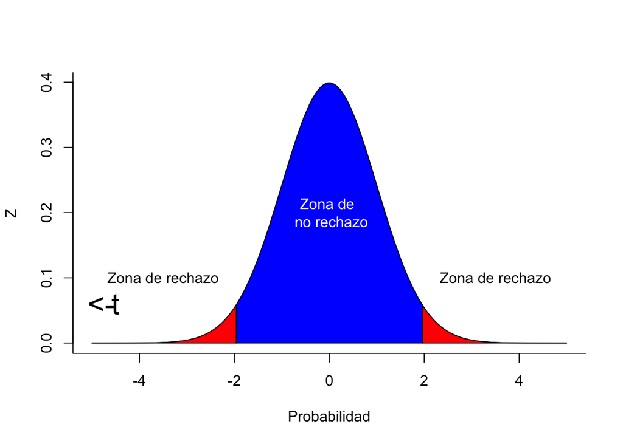

```r
plot.norm.test(M.prom, mu0 = mu0.1, sigma = sd.1)
```

6. Calculamos el valor de p (Pero como aún no ven es, no lo voy a poner)
7. Decisión estadística: Como mi T observada es menor (muy menor), cae en la zona de rechazo, por lo tanto rechazo la H0
8. Conclusión biológica: El promedio del promedio de la calificación de las estudiantes mujeres es diferente de 9, en este caso es menor a 9.

#### 2) Les estudiantes con pareja (edo.civil) tienen, en promedio, una edad mayor a 21 años. Supongan una desviación estándar poblacional de 1 año.

Crearemos los objetos que contienen los datos del problema 1

```r
edad.no.soltero <- alumnos$edad[alumnos$edo.civil == "Con"]
mu0.2 <- 21
sd.2 <- 1
```

1. Hipótesis estadísticas: Como la premisa del inciso nos dice que tengan una edad mayor a 21 años, eso nos indica que se trata de la hipótesis alternativa ya que no tiene ningún término de igual (=), por lo tanto las HE quedarían así.

H0: mu edad con pareja <= 21 (menor que o igual)

H1: mu edad con pareja > 21 (mayor que)

2. Como tenemos símbolos de menor y mayor que, la prueba será de una sola cola. Como nos importa (H1) que mu sea mayor a mu0 (21) entonces la cola será la derecha que cae del lado de los valores positivos.
3. Como la sigma es conocida usaré la distribución de Z
4. Calculamos la zona de rechazo. Solo calculamos la parte superior ya que la inferior va a más infinito por ser una prueba de cola derecha

```r
ZR.Sup.2 <- qnorm(1-alfa)
```

5. Calculamos nuestra T

```r
T.obs.2 <- (mean(edad.no.soltero)-mu0.2)/(sd.2/sqrt(length(edad.no.soltero)))
print(paste("Mi T observada tiene un valor de ",T.obs.2,"y la zona de rechazo va de ",ZR.Sup.2, "a infinito"))
```

```
## [1] "Mi T observada tiene un valor de  0.185695338177056 y la zona de rechazo va de  1.64485362695147 a infinito"
```

Graficamos la zona de rechazo y vemos donde cae T. (Recuerden que pueden hacer esto a manita para que no sufran haciendolo en R)

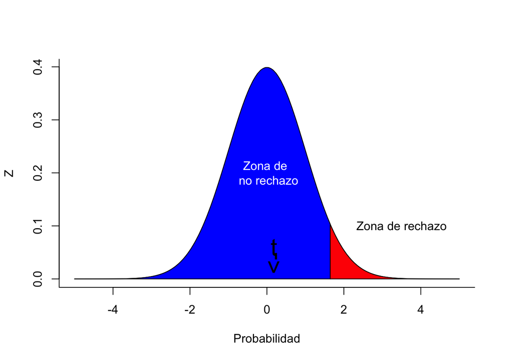

```r
plot.norm.test(edad.no.soltero, mu0 = mu0.2, sigma = sd.2, cola = "derecha")
```

f) Calculamos el valor de p (auún no lo ven así que no lo voy a aponer)

#### 3) Les estudiantes de laboratorio tienen, en promedio, un peso mayor a les estudiantes de campo. Supongan una desviación estándar poblacional para ambos conjuntos de estudiantes de 2 kg.

Guardamos las variables de interés y sus parámetros

```r
sd.3 <- 2
peso.lab <- alumnos$peso[alumnos$tipo.biol == "Lab"]
peso.campo <- alumnos$peso[alumnos$tipo.biol == "Campo"]
```

1. hipótesis estadísticas: Como estamos comparando dos poblaciones, ahora no va a haber una mu0, solo dos mus poblacionales. Además, como queremos saber si peso.lab > peso.campo, eso nos da la H1.

H0: mu peso.lab <= mu peso.campo (menor que o igual)

H1: mu peso.lab > mu peso.campo (mayor que)

2. Como tenemos mayor que y menor que, la prueba va a ser de una sola cola. Y como nos importa (y esto es bien importante, matener siempre el orden de quien es mu1 y mu2) que mu1 (lab) sea mayor que mu2 (campo) entonces será una prueba de cola derecha.
3. Como conozco la sigma de ambos conjuntos, se utilizará una distribución de Z
4. Calculamos la zona de rechazo

```r
ZR.Sup.3 <- qnorm(1-alfa)
```

5. Calculamos T

```r
T.obs.3 <- (mean(peso.lab)-mean(peso.campo))/sqrt((sd.3/length(peso.lab))+(sd.3/length(peso.campo)))
print(paste("Mi T observada tiene un valor de ",T.obs.3,"y la zona de rechazo va de ",ZR.Sup.3, "a infinito"))
```

```
## [1] "Mi T observada tiene un valor de  -14.2066147146176 y la zona de rechazo va de  1.64485362695147 a infinito"
```

Graficamos nuestro valor de T para verlo más fácil

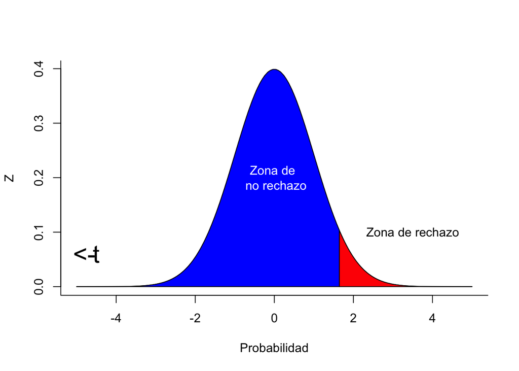

```r
plot.norm.test(data = peso.lab, data2 = peso.campo, sigma = sd.3, sigma2 = sd.3, cola = "derecha")
```

f) Calculamos nuestro valor de p (no lo haré aún)

#### 4) Los estudiantes hombres tienen, en promedio, una estatura mayor que las estudiantes mujeres. Supongan una desviación estándar poblacional para hombres de 0.15 m y para mujeres de 0.13 m.

Cargamos los datos de este problema

```r
est.h <- alumnos$estatura[alumnos$sexo == "Hombre"]
est.m <- alumnos$estatura[alumnos$sexo == "Mujer"]
sd.h.4 <- 0.15
sd.m.4 <- 0.13
```

1. hipótesis estadísticas: Como estamos comparando dos poblaciones, ahora no va a haber una mu0, solo dos mus poblacionales. Además, como queremos saber si est.h > est.m, eso nos da la H1 porque no tiene iguales.

H0: mu est.h <= mu est.m (menor que o igual)

H1: mu est.h > mu est.m (mayor que)

2. Como tenemos mayor que y menor que, la prueba va a ser de una sola cola. Y como nos importa (y esto es bien importante, matener siempre el orden de quien es mu1 y mu2) que mu1 (est.h) sea mayor que mu2 (est.m) entonces será una prueba de cola derecha.
3. Como conozco la sigma de ambos conjuntos, se utilizará una distribución de Z
4. Calculamos la zona de rechazo

```r
ZR.Sup.4 <- qnorm(1-alfa)
```

5. Calculamos T

```r
T.obs.4 <- (mean(est.h)-mean(est.m))/sqrt((sd.h.4/length(est.h))+(sd.m.4/length(est.m)))
print(paste("Mi T observada tiene un valor de ",T.obs.4,"y la zona de rechazo va de ",ZR.Sup.4, "a infinito"))
```

```
## [1] "Mi T observada tiene un valor de  2.01389942864817 y la zona de rechazo va de  1.64485362695147 a infinito"
```

Graficamos nuestro valor de T para verlo más fácil

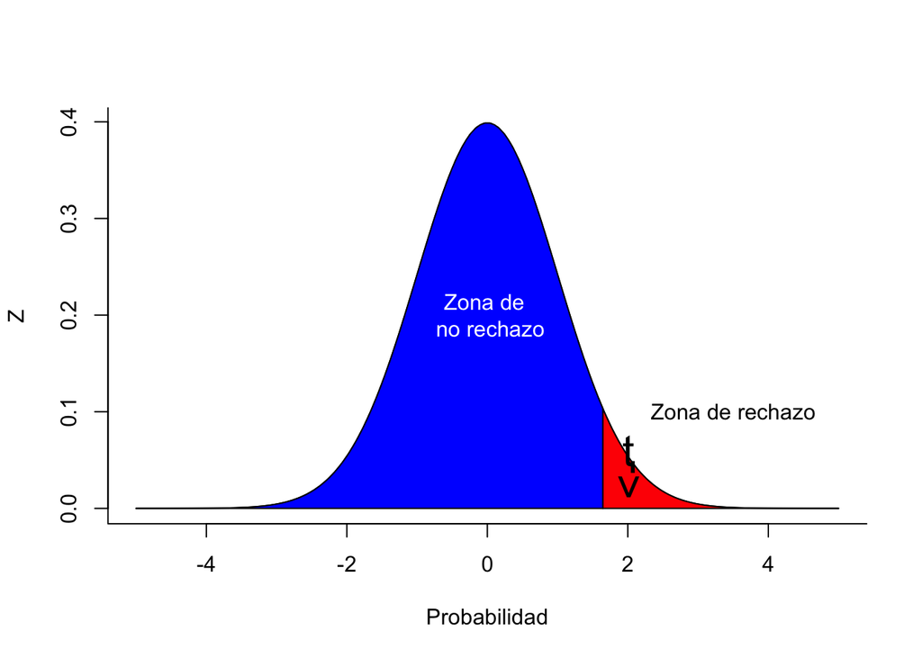

```r
plot.norm.test(data = est.h, data2 = est.m, sigma = sd.h.4, sigma2 = sd.m.4, cola ="derecha")
```

f) Calculamos nuestro valor de p (no lo haré aún)

7. Decisión estadística: Como mi T obs cae en la zona de rechazo, decidimos rechazar H0. Así esté cerca de la zona de no rechazo, se rechaza H0
8. Conclusión biológica: La estatura de les estudiantes hombres de bioestadística es mayor que la estatura de les estudiantes muejeres.

#### Notas finales:

Para las pruebas de dos mus poblacionales es importante tener muy claro quién es mu1 y mu2 y ponerlas siempre en ese orden en todos los cálculos que hagan ya que no es lo mismo mu1-mu2 que mu2-mu1. Cuidado con eso